# Valoración de opciones americanas mediante métodos numéricos

## 5. Método de Monte Carlo (LSM — Longstaff-Schwartz)

### Idea del método

La simulación de Monte Carlo genera muchas trayectorias aleatorias del precio del activo, siguiendo el modelo de movimiento browniano geométrico:

$$S_{t+\Delta t} = S_t \cdot \exp\left[\left(r - \frac{\sigma^2}{2}\right)\Delta t + \sigma\sqrt{\Delta t}\; Z\right]$$

donde Z es una variable aleatoria normal estándar.

El problema con las opciones americanas es que no basta con simular y calcular el payoff al final (eso solo vale para europeas). Hay que decidir, en cada momento de la trayectoria, si conviene ejercer o esperar. Para eso se usa el algoritmo de Longstaff y Schwartz (2001):

1. Se generan M trayectorias del precio con N pasos temporales.
2. Se parte del vencimiento (donde el payoff es conocido) y se retrocede paso a paso.
3. En cada paso, para las trayectorias que están in-the-money, se hace una regresión por mínimos cuadrados del valor de continuación sobre el precio actual. Esto da una estimación de cuánto vale esperar.
4. Se compara esa estimación con el payoff de ejercer ahora, y se decide qué hacer en cada trayectoria.
5. El precio final es el promedio descontado de los flujos óptimos de todas las trayectorias.

La regresión es la pieza clave: permite estimar el valor de continuación sin necesidad de construir un árbol ni resolver una EDP.

```python
def precio_monte_carlo(S0, K, T, r, sigma, tipo='put', M=50000, N=100, semilla=42):
    """
    Calcula el precio de una opción americana mediante simulación de
    Monte Carlo con el algoritmo LSM (Longstaff-Schwartz).

    Parámetros
    ----------
    S0     : float - Precio actual del subyacente
    K      : float - Precio de ejercicio
    T      : float - Tiempo al vencimiento (años)
    r      : float - Tasa libre de riesgo
    sigma  : float - Volatilidad
    tipo   : str   - 'call' o 'put'
    M      : int   - Número de trayectorias simuladas
    N      : int   - Número de pasos temporales
    semilla: int   - Semilla aleatoria (para reproducibilidad)

    Retorna
    -------
    precio       : float      - Valor de la opción americana
    trayectorias : np.array   - Matriz de trayectorias (M x N+1), para visualización
    """
    np.random.seed(semilla)
    dt = T / N
    descuento = np.exp(-r * dt)

    # --- Generar trayectorias del subyacente ---
    # Cada fila es una trayectoria, cada columna es un paso temporal
    Z = np.random.standard_normal((M, N))
    S = np.zeros((M, N + 1))
    S[:, 0] = S0

    for t in range(1, N + 1):
        S[:, t] = S[:, t-1] * np.exp((r - 0.5 * sigma**2) * dt + sigma * np.sqrt(dt) * Z[:, t-1])

    # --- Payoff en cada punto de la malla ---
    if tipo == 'call':
        payoff = np.maximum(S - K, 0.0)
    else:
        payoff = np.maximum(K - S, 0.0)

    # --- Algoritmo LSM: decidir cuándo ejercer ---
    # flujo_caja[i] guarda el flujo descontado que genera la trayectoria i
    flujo_caja = payoff[:, -1].copy()  # Inicializar con el payoff en T
    momento_ejercicio = np.full(M, N)  # Paso en el que se ejerce (inicialmente, al final)

    # Recorrer hacia atrás desde el penúltimo paso hasta el primero
    for t in range(N - 1, 0, -1):
        # Solo interesan las trayectorias que están in-the-money en este paso
        itm = payoff[:, t] > 0

        if np.sum(itm) == 0:
            # Ninguna trayectoria está ITM en este paso, no hay nada que hacer
            continue

        # Precios y flujos de las trayectorias ITM
        S_itm = S[itm, t]

        # Flujos futuros descontados al paso t (de las trayectorias ITM)
        pasos_hasta_ejercicio = momento_ejercicio[itm] - t
        flujo_futuro = payoff[itm, momento_ejercicio[itm]] * descuento ** pasos_hasta_ejercicio

        # Regresión: estimar el valor de continuación como función de S.
        # Se usa un polinomio de grado 2 (suficiente en la práctica).
        X = np.column_stack([np.ones_like(S_itm), S_itm, S_itm**2])

        # Resolver la regresión por mínimos cuadrados
        coef, _, _, _ = np.linalg.lstsq(X, flujo_futuro, rcond=None)
        valor_continuacion = X @ coef

        # Decidir: ¿conviene ejercer ahora o esperar?
        ejercer_ahora = payoff[itm, t] >= valor_continuacion

        # Actualizar las trayectorias que deciden ejercer en este paso
        indices_itm = np.where(itm)[0]
        indices_ejercer = indices_itm[ejercer_ahora]

        flujo_caja[indices_ejercer] = payoff[indices_ejercer, t]
        momento_ejercicio[indices_ejercer] = t

    # --- Precio final: promedio descontado de los flujos óptimos ---
    flujos_descontados = flujo_caja * descuento ** momento_ejercicio
    precio = float(np.mean(flujos_descontados))

    return precio, S

print("Función precio_monte_carlo() definida.")
```

```
Función precio_monte_carlo() definida.
```

### Prueba del método de Monte Carlo

Se calcula el precio de la put americana con los parámetros base, variando el número de trayectorias (M). Al ser un método aleatorio, los resultados cambian ligeramente en cada ejecución (salvo que se fije la semilla). Lo esperable es que al aumentar M el precio se estabilice y se acerque a los valores obtenidos con los otros dos métodos.

```python
# Prueba con distintos números de trayectorias
trayectorias_prueba = [5000, 10000, 25000, 50000, 100000, 200000]

print(f"{'M':>8}  {'Precio':>12}  {'Tiempo (ms)':>12}")
print("-" * 38)

for M in trayectorias_prueba:
    t0 = time.perf_counter()
    precio_mc, _ = precio_monte_carlo(S0, K, T, r, sigma, tipo, M=M, N=100)
    ms = (time.perf_counter() - t0) * 1000
    print(f"{M:>8}  {precio_mc:>12.6f}  {ms:>12.2f}")

# Comparación con los otros métodos
print()
print(f"Referencia binomial (N=500):        {precio_bin_ref:.6f}")
print(f"Referencia dif. finitas (200x800):  {precio_fd_ref:.6f}")
print(f"Referencia europea (B-S):           {precio_eu_ref:.6f}")
```

```
       M        Precio   Tiempo (ms)
--------------------------------------
    5000      6.158674         51.01
   10000      6.154770         70.36
   25000      6.085801        187.49
   50000      6.067423        405.16
  100000      6.066472        919.62
  200000      6.060015       2022.60

Referencia binomial (N=500):        6.088810
Referencia dif. finitas (200x800):  6.078416
Referencia europea (B-S):           5.573526
```

### Visualización de trayectorias simuladas

Se dibujan algunas de las trayectorias generadas por Monte Carlo para ver cómo se mueve el precio del subyacente. Esto da una idea visual de la incertidumbre del activo y de por qué el payoff de la opción varía entre trayectorias.

Se muestran solo unas pocas trayectorias (de las miles simuladas) para que la gráfica sea legible.

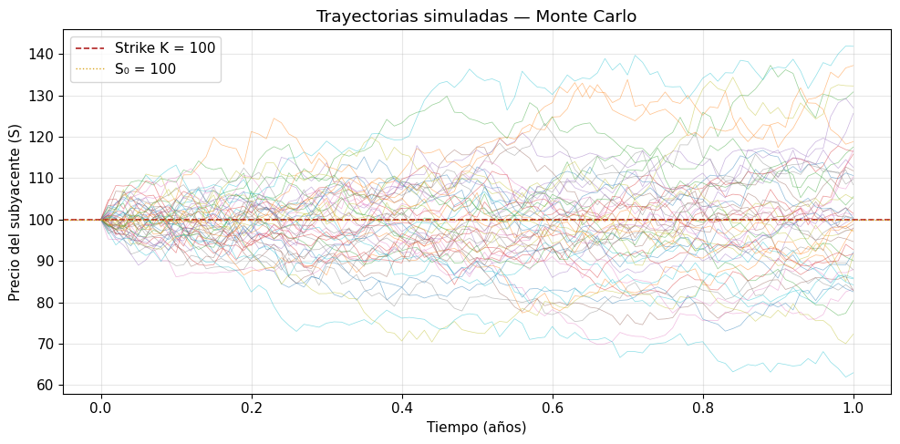

```
Se muestran 50 de las 10000 trayectorias simuladas.
```

```python
# Generar trayectorias (se reutilizan las de la función)
_, trayectorias = precio_monte_carlo(S0, K, T, r, sigma, tipo, M=10000, N=100)

# Eje temporal
pasos_t = np.linspace(0, T, trayectorias.shape[1])

# Dibujar 50 trayectorias al azar
np.random.seed(0)
indices = np.random.choice(trayectorias.shape[0], size=50, replace=False)

plt.figure(figsize=(10, 5))
for i in indices:
    plt.plot(pasos_t, trayectorias[i, :], linewidth=0.5, alpha=0.5)

plt.axhline(K, color='firebrick', linewidth=1.2, linestyle='--', label=f'Strike K = {K}')
plt.axhline(S0, color='goldenrod', linewidth=1.0, linestyle=':', label=f'S₀ = {S0}')
plt.xlabel('Tiempo (años)')
plt.ylabel('Precio del subyacente (S)')
plt.title('Trayectorias simuladas — Monte Carlo')
plt.legend()
plt.tight_layout()
plt.show()

print(f"Se muestran 50 de las {trayectorias.shape[0]} trayectorias simuladas.")
```

### Convergencia del método de Monte Carlo

Se estudia cómo evoluciona el precio al aumentar el número de trayectorias (M). Al ser un método aleatorio, se ejecuta varias veces con cada valor de M para obtener la media y la desviación típica. Esto permite ver no solo si converge, sino también cuánta variabilidad tiene el resultado.

```
       M       Media  Desv. típ.   Tiempo medio (ms)
----------------------------------------------------
    1000    6.270864    0.226488                7.93
    5000    6.099379    0.136287               35.82
   10000    6.085559    0.107072               70.44
   25000    6.082700    0.057973              197.85
   50000    6.069101    0.037001              466.70
  100000    6.066221    0.027095             1008.09
```

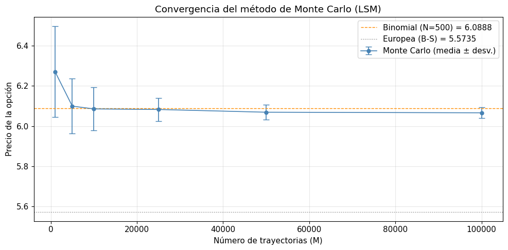

```python
# Valores de M para el estudio de convergencia
valores_M = [1000, 5000, 10000, 25000, 50000, 100000]

# Repeticiones por cada valor de M (para medir variabilidad)
repeticiones = 10

print(f"{'M':>8}  {'Media':>10}  {'Desv. típ.':>10}  {'Tiempo medio (ms)':>18}")
print("-" * 52)

medias_mc = []
desviaciones_mc = []

for M in valores_M:
    precios_rep = []
    tiempos_rep = []

    for rep in range(repeticiones):
        t0 = time.perf_counter()
        p, _ = precio_monte_carlo(S0, K, T, r, sigma, tipo, M=M, N=100, semilla=rep)
        ms = (time.perf_counter() - t0) * 1000
        precios_rep.append(p)
        tiempos_rep.append(ms)

    media = np.mean(precios_rep)
    desv = np.std(precios_rep)
    tiempo_medio = np.mean(tiempos_rep)
    medias_mc.append(media)
    desviaciones_mc.append(desv)

    print(f"{M:>8}  {media:>10.6f}  {desv:>10.6f}  {tiempo_medio:>18.2f}")

# Gráfica con barras de error
plt.figure(figsize=(10, 5))
plt.errorbar(valores_M, medias_mc, yerr=desviaciones_mc, fmt='o-', color='steelblue',
             linewidth=1.2, markersize=5, capsize=4, label='Monte Carlo (media ± desv.)')
plt.axhline(precio_bin_ref, color='darkorange', linestyle='--', linewidth=1.0,
            label=f'Binomial (N=500) = {precio_bin_ref:.4f}')
plt.axhline(precio_eu_ref, color='gray', linestyle=':', linewidth=1.0,
            label=f'Europea (B-S) = {precio_eu_ref:.4f}')
plt.xlabel('Número de trayectorias (M)')
plt.ylabel('Precio de la opción')
plt.title('Convergencia del método de Monte Carlo (LSM)')
plt.legend()
plt.tight_layout()
plt.show()
```

```python
# Resumen del método de Monte Carlo
precio_mc_ref, _ = precio_monte_carlo(S0, K, T, r, sigma, tipo, M=100000, N=100)

t0 = time.perf_counter()
_ = precio_monte_carlo(S0, K, T, r, sigma, tipo, M=100000, N=100)
tiempo_mc = (time.perf_counter() - t0) * 1000

print("=" * 55)
print("   RESUMEN DEL MÉTODO DE MONTE CARLO (LSM)")
print("=" * 55)
print()
print(f"  Precio americana (M=100000):      {precio_mc_ref:.6f}")
print(f"  Precio binomial (N=500):          {precio_bin_ref:.6f}")
print(f"  Precio dif. finitas (200x800):    {precio_fd_ref:.6f}")
print(f"  Precio europea (B-S):             {precio_eu_ref:.6f}")
print(f"  Diferencia con binomial:          {abs(precio_mc_ref - precio_bin_ref):.6f}")
print(f"  Tiempo de cálculo (M=100000):     {tiempo_mc:.2f} ms")
print()
print("  Observaciones:")
print("  - El precio converge al aumentar M, con variabilidad decreciente")
print("  - Existe un ligero sesgo a la baja (limitación conocida del LSM)")
print("  - Es el método más lento de los tres para precisión comparable")
print("  - A cambio, es el más flexible (extensible a problemas complejos)")
print()
print("  Bloque listo. Siguiente paso: comparación de los tres métodos.")
print("=" * 55)
```

```
=======================================================
   RESUMEN DEL MÉTODO DE MONTE CARLO (LSM)
=======================================================

  Precio americana (M=100000):      6.066472
  Precio binomial (N=500):          6.088810
  Precio dif. finitas (200x800):    6.078416
  Precio europea (B-S):             5.573526
  Diferencia con binomial:          0.022338
  Tiempo de cálculo (M=100000):     920.14 ms

  Observaciones:
  - El precio converge al aumentar M, con variabilidad decreciente
  - Existe un ligero sesgo a la baja (limitación conocida del LSM)
  - Es el método más lento de los tres para precisión comparable
  - A cambio, es el más flexible (extensible a problemas complejos)

  Bloque listo. Siguiente paso: comparación de los tres métodos.
=======================================================
```

## 6. Comparación de los tres métodos

Con los tres métodos implementados y validados, se procede a compararlos de forma directa. Se analizan los precios obtenidos, los tiempos de ejecución y las griegas calculadas por cada uno. El objetivo es determinar las ventajas y limitaciones de cada enfoque.

### Comparación de precios y tiempos de ejecución

Se ejecutan los tres métodos con los parámetros base y una configuración de precisión razonable para cada uno. Se mide el tiempo de cada cálculo y se comparan los precios obtenidos.

```
==============================================================
   COMPARACIÓN DE PRECIOS Y TIEMPOS DE EJECUCIÓN
==============================================================

  Método                           Precio    Tiempo (ms)
  ----------------------------------------------------
  Binomial (N=500)               6.088810          23.53
  Dif. finitas (200x800)         6.078416          20.88
  Monte Carlo (M=100000)         6.066472         930.65
  ----------------------------------------------------
  Europea (B-S, referencia)      5.573526

  Diferencias respecto al binomial:
    Dif. finitas:  0.010394
    Monte Carlo:   0.022338
```

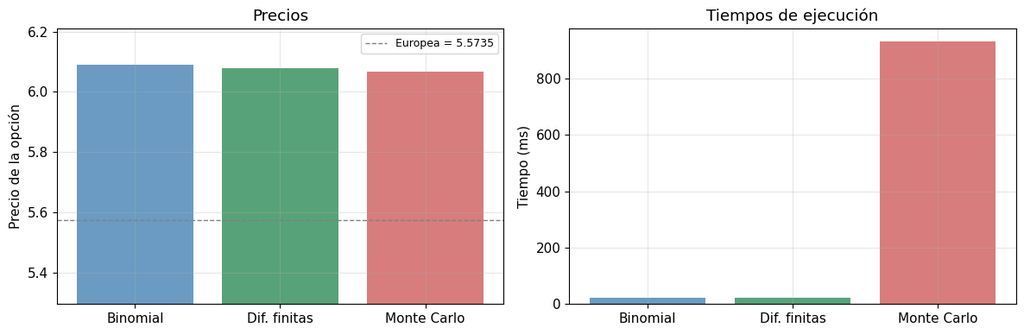

```python
# ============================================================
# Comparación de precios y tiempos de ejecución
# ============================================================

# --- Binomial ---
t0 = time.perf_counter()
p_bin = precio_binomial(S0, K, T, r, sigma, tipo, N=500)
t_bin = (time.perf_counter() - t0) * 1000

# --- Diferencias finitas ---
t0 = time.perf_counter()
p_fd, _, _ = precio_diferencias_finitas(S0, K, T, r, sigma, tipo, N_S=200, N_T=800)
t_fd = (time.perf_counter() - t0) * 1000

# --- Monte Carlo ---
t0 = time.perf_counter()
p_mc, _ = precio_monte_carlo(S0, K, T, r, sigma, tipo, M=100000, N=100)
t_mc = (time.perf_counter() - t0) * 1000

# --- Europeo (referencia) ---
p_eu = precio_bs_europeo(S0, K, T, r, sigma, tipo)

# Mostrar resultados
print("=" * 62)
print("   COMPARACIÓN DE PRECIOS Y TIEMPOS DE EJECUCIÓN")
print("=" * 62)
print()
print(f"  {'Método':<28} {'Precio':>10} {'Tiempo (ms)':>14}")
print(f"  {'-'*52}")
print(f"  {'Binomial (N=500)':<28} {p_bin:>10.6f} {t_bin:>14.2f}")
print(f"  {'Dif. finitas (200x800)':<28} {p_fd:>10.6f} {t_fd:>14.2f}")
print(f"  {'Monte Carlo (M=100000)':<28} {p_mc:>10.6f} {t_mc:>14.2f}")
print(f"  {'-'*52}")
print(f"  {'Europea (B-S, referencia)':<28} {p_eu:>10.6f}")
print()

# Diferencias respecto al binomial (que es el más preciso de los tres)
print("  Diferencias respecto al binomial:")
print(f"    Dif. finitas:  {abs(p_fd - p_bin):.6f}")
print(f"    Monte Carlo:   {abs(p_mc - p_bin):.6f}")
print()

# Gráfica de barras comparativa
fig, (ax1, ax2) = plt.subplots(1, 2, figsize=(12, 4))

metodos = ['Binomial', 'Dif. finitas', 'Monte Carlo']
precios = [p_bin, p_fd, p_mc]
tiempos = [t_bin, t_fd, t_mc]
colores = ['steelblue', 'seagreen', 'indianred']

# Precios
ax1.bar(metodos, precios, color=colores, alpha=0.8)
ax1.axhline(p_eu, color='gray', linestyle='--', linewidth=1.0, label=f'Europea = {p_eu:.4f}')
ax1.set_ylabel('Precio de la opción')
ax1.set_title('Precios')
ax1.legend(fontsize=9)
ax1.set_ylim(p_eu * 0.95, max(precios) * 1.02)

# Tiempos
ax2.bar(metodos, tiempos, color=colores, alpha=0.8)
ax2.set_ylabel('Tiempo (ms)')
ax2.set_title('Tiempos de ejecución')

plt.tight_layout()
plt.show()
```

### Cálculo de los griegos

Los griegos miden la sensibilidad del precio de la opción ante cambios en los parámetros de mercado. Se calculan numéricamente mediante diferencias finitas sobre el propio precio de la opción: se perturba ligeramente un parámetro, se recalcula el precio y se estima la derivada.

Las cinco griegas que se calculan son:

- **Delta (Δ)**: sensibilidad al precio del subyacente (∂V/∂S)
- **Gamma (Γ)**: variación de Delta ante cambios en S (∂²V/∂S²)
- **Theta (Θ)**: pérdida de valor por el paso del tiempo (∂V/∂t), expresada por día
- **Vega (ν)**: sensibilidad ante cambios en la volatilidad (∂V/∂σ)
- **Rho (ρ)**: sensibilidad ante cambios en el tipo de interés (∂V/∂r)

Se calculan con los tres métodos para poder compararlas entre sí.

```python
def calcular_griegos(funcion_precio, S0, K, T, r, sigma, tipo, **kwargs):
    """
    Calcula los cinco griegos de forma numérica para cualquiera de los
    tres métodos. Se perturba cada parámetro ligeramente y se estima
    la derivada por diferencias centrales.

    Parámetros
    ----------
    funcion_precio : callable - Función que devuelve el precio (primer elemento si es tupla)
    S0, K, T, r, sigma, tipo : parámetros de la opción
    **kwargs : parámetros adicionales del método (N, N_S, N_T, M, etc.)

    Retorna
    -------
    dict con Delta, Gamma, Theta, Vega, Rho
    """
    # Función auxiliar: extraer solo el precio (algunas funciones devuelven tuplas)
    def precio(S0_, K_, T_, r_, sigma_, tipo_):
        resultado = funcion_precio(S0_, K_, T_, r_, sigma_, tipo_, **kwargs)
        if isinstance(resultado, tuple):
            return resultado[0]
        return resultado

    # Perturbaciones (pequeñas, pero no demasiado para evitar ruido numérico)
    h_S = S0 * 0.01          # 1% del precio para Delta y Gamma
    h_sigma = 0.001           # 0.1% para Vega
    h_r = 0.0001              # 0.01% para Rho
    h_T = max(T * 0.01, 1e-4) # 1% del tiempo para Theta

    # Precio base
    p0 = precio(S0, K, T, r, sigma, tipo)

    # Delta = ∂V/∂S (diferencia central)
    p_up_S = precio(S0 + h_S, K, T, r, sigma, tipo)
    p_dn_S = precio(S0 - h_S, K, T, r, sigma, tipo)
    delta = (p_up_S - p_dn_S) / (2 * h_S)

    # Gamma = ∂²V/∂S² (diferencia central de segundo orden)
    gamma = (p_up_S - 2 * p0 + p_dn_S) / (h_S ** 2)

    # Theta = ∂V/∂t (se reduce T un poco; signo negativo porque al pasar el tiempo T disminuye)
    p_menos_T = precio(S0, K, T - h_T, r, sigma, tipo)
    theta = -(p_menos_T - p0) / h_T / 365  # Por día

    # Vega = ∂V/∂σ
    p_up_sigma = precio(S0, K, T, r, sigma + h_sigma, tipo)
    vega = (p_up_sigma - p0) / h_sigma

    # Rho = ∂V/∂r
    p_up_r = precio(S0, K, T, r + h_r, sigma, tipo)
    rho = (p_up_r - p0) / h_r

    return {
        'Delta': delta,
        'Gamma': gamma,
        'Theta': theta,
        'Vega':  vega,
        'Rho':   rho,
    }

print("Función calcular_griegos() definida.")
```

```
Función calcular_griegos() definida.
```

```python
# ============================================================
# Cálculo de griegos con los tres métodos
# ============================================================

# Binomial
griegos_bin = calcular_griegos(precio_binomial, S0, K, T, r, sigma, tipo, N=500)

# Diferencias finitas (se necesita una función que acepte los mismos argumentos)
def _precio_fd(S0, K, T, r, sigma, tipo, N_S=200, N_T=800):
    return precio_diferencias_finitas(S0, K, T, r, sigma, tipo, N_S, N_T)

griegos_fd = calcular_griegos(_precio_fd, S0, K, T, r, sigma, tipo, N_S=200, N_T=800)

# Monte Carlo
def _precio_mc(S0, K, T, r, sigma, tipo, M=100000, N=100):
    return precio_monte_carlo(S0, K, T, r, sigma, tipo, M, N)

griegos_mc = calcular_griegos(_precio_mc, S0, K, T, r, sigma, tipo, M=100000, N=100)

# Mostrar tabla comparativa
print("=" * 66)
print("   COMPARACIÓN DE GRIEGOS")
print("=" * 66)
print()
print(f"  {'Griego':<10} {'Binomial':>14} {'Dif. finitas':>14} {'Monte Carlo':>14}")
print(f"  {'-'*52}")

for g in ['Delta', 'Gamma', 'Theta', 'Vega', 'Rho']:
    vb = griegos_bin[g]
    vf = griegos_fd[g]
    vm = griegos_mc[g]
    print(f"  {g:<10} {vb:>+14.6f} {vf:>+14.6f} {vm:>+14.6f}")

print()
print("  Nota: Theta expresada por día. Vega por unidad de volatilidad.")
```

```
==================================================================
   COMPARACIÓN DE GRIEGOS
==================================================================

  Griego           Binomial   Dif. finitas    Monte Carlo
  ----------------------------------------------------
  Delta           -0.411072      -0.411467      -0.412070
  Gamma           +0.031783      +0.046061      +0.025747
  Theta           +0.006154      +0.006174      +0.006410
  Vega           +37.483744     +37.565387     +36.372193
  Rho            -30.195668     -30.240790     -25.686538

  Nota: Theta expresada por día. Vega por unidad de volatilidad.
```

### Visualización comparativa de los griegos

Se representan los valores de cada griego en un gráfico de barras agrupado para facilitar la comparación visual entre métodos. Las griegas con magnitudes muy distintas (Vega y Rho son mucho mayores que Delta o Gamma) se separan en paneles diferentes para que la escala no oculte las diferencias.

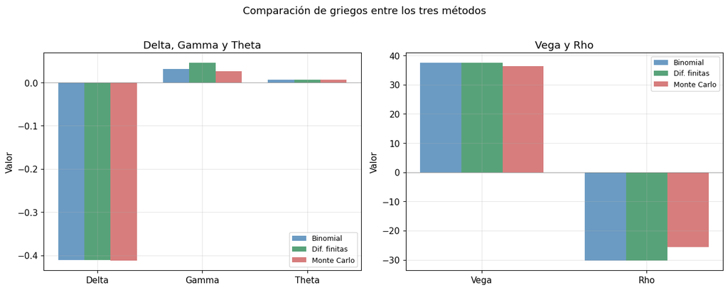

```python
# Separar griegos en dos grupos por escala
griegos_pequeños = ['Delta', 'Gamma', 'Theta']
griegos_grandes = ['Vega', 'Rho']

fig, (ax1, ax2) = plt.subplots(1, 2, figsize=(13, 5))

# --- Panel izquierdo: Delta, Gamma, Theta ---
x = np.arange(len(griegos_pequeños))
ancho = 0.25

vals_bin = [griegos_bin[g] for g in griegos_pequeños]
vals_fd  = [griegos_fd[g] for g in griegos_pequeños]
vals_mc  = [griegos_mc[g] for g in griegos_pequeños]

ax1.bar(x - ancho, vals_bin, ancho, color='steelblue', alpha=0.8, label='Binomial')
ax1.bar(x,         vals_fd,  ancho, color='seagreen',  alpha=0.8, label='Dif. finitas')
ax1.bar(x + ancho, vals_mc,  ancho, color='indianred',  alpha=0.8, label='Monte Carlo')
ax1.set_xticks(x)
ax1.set_xticklabels(griegos_pequeños)
ax1.set_ylabel('Valor')
ax1.set_title('Delta, Gamma y Theta')
ax1.legend(fontsize=9)
ax1.axhline(0, color='gray', linewidth=0.5)

# --- Panel derecho: Vega, Rho ---
x2 = np.arange(len(griegos_grandes))

vals_bin2 = [griegos_bin[g] for g in griegos_grandes]
vals_fd2  = [griegos_fd[g] for g in griegos_grandes]
vals_mc2  = [griegos_mc[g] for g in griegos_grandes]

ax2.bar(x2 - ancho, vals_bin2, ancho, color='steelblue', alpha=0.8, label='Binomial')
ax2.bar(x2,         vals_fd2,  ancho, color='seagreen',  alpha=0.8, label='Dif. finitas')
ax2.bar(x2 + ancho, vals_mc2,  ancho, color='indianred',  alpha=0.8, label='Monte Carlo')
ax2.set_xticks(x2)
ax2.set_xticklabels(griegos_grandes)
ax2.set_ylabel('Valor')
ax2.set_title('Vega y Rho')
ax2.legend(fontsize=9)
ax2.axhline(0, color='gray', linewidth=0.5)

plt.suptitle('Comparación de griegos entre los tres métodos', fontsize=13, y=1.02)
plt.tight_layout()
plt.show()
```

### Tabla resumen y conclusiones

Se recopila toda la información en una tabla comparativa final que recoge precios, tiempos, precisión relativa y características de cada método.

```python
# ============================================================
# Tabla resumen final (interactiva — se recalcula todo al ejecutar)
# ============================================================

# --- Recalcular precios y tiempos ---
t0 = time.perf_counter()
p_bin = precio_binomial(S0, K, T, r, sigma, tipo, N=500)
t_bin = (time.perf_counter() - t0) * 1000

t0 = time.perf_counter()
p_fd, _, _ = precio_diferencias_finitas(S0, K, T, r, sigma, tipo, N_S=200, N_T=800)
t_fd = (time.perf_counter() - t0) * 1000

t0 = time.perf_counter()
p_mc, _ = precio_monte_carlo(S0, K, T, r, sigma, tipo, M=100000, N=100)
t_mc = (time.perf_counter() - t0) * 1000

p_eu = precio_bs_europeo(S0, K, T, r, sigma, tipo)

# --- Recalcular griegos ---
griegos_bin = calcular_griegos(precio_binomial, S0, K, T, r, sigma, tipo, N=500)
griegos_fd = calcular_griegos(_precio_fd, S0, K, T, r, sigma, tipo, N_S=200, N_T=800)
griegos_mc = calcular_griegos(_precio_mc, S0, K, T, r, sigma, tipo, M=100000, N=100)

# --- Determinar el más rápido y el más preciso ---
tiempos = {'Binomial': t_bin, 'Dif. finitas': t_fd, 'Monte Carlo': t_mc}
mas_rapido = min(tiempos, key=tiempos.get)

difs = {'Binomial': 0.0, 'Dif. finitas': abs(p_fd - p_bin), 'Monte Carlo': abs(p_mc - p_bin)}
mas_alejado = max(difs, key=difs.get)

# --- Mostrar ---
print("=" * 75)
print("   TABLA RESUMEN — COMPARACIÓN DE LOS TRES MÉTODOS")
print("=" * 75)
print()
print(f"  Parámetros: S0={S0}, K={K}, T={T}, r={r}, sigma={sigma}, tipo={tipo}")
print()

# Precios y tiempos
print("  PRECIOS Y TIEMPOS")
print(f"  {'-'*65}")
print(f"  {'Método':<25} {'Precio':>10} {'Tiempo':>10} {'Dif. vs bin.':>14}")
print(f"  {'-'*65}")
print(f"  {'Binomial (N=500)':<25} {p_bin:>10.6f} {t_bin:>8.1f} ms {'(ref.)':>14}")
print(f"  {'Dif. finitas (200x800)':<25} {p_fd:>10.6f} {t_fd:>8.1f} ms {abs(p_fd-p_bin):>14.6f}")
print(f"  {'Monte Carlo (M=100K)':<25} {p_mc:>10.6f} {t_mc:>8.1f} ms {abs(p_mc-p_bin):>14.6f}")
print(f"  {'Europea (B-S)':<25} {p_eu:>10.6f}")
print(f"  {'-'*65}")
print(f"  Prima ejercicio anticipado (bin. vs B-S): {p_bin - p_eu:.6f}")
print(f"  Método más rápido: {mas_rapido} ({tiempos[mas_rapido]:.1f} ms)")
print(f"  Mayor desviación respecto al binomial: {mas_alejado} ({difs[mas_alejado]:.6f})")
print()

# Griegos
print("  GRIEGOS")
print(f"  {'-'*65}")
print(f"  {'Griego':<10} {'Binomial':>14} {'Dif. finitas':>14} {'Monte Carlo':>14}")
print(f"  {'-'*65}")
for g in ['Delta', 'Gamma', 'Theta', 'Vega', 'Rho']:
    vb = griegos_bin[g]
    vf = griegos_fd[g]
    vm = griegos_mc[g]
    # Marcar con (*) el griego donde Monte Carlo se desvía más
    dif_mc = abs(vm - vb)
    dif_fd = abs(vf - vb)
    mayor_dif = max(dif_mc, dif_fd)
    marca = ' *' if dif_mc == mayor_dif and dif_mc > 0.01 else ''
    print(f"  {g:<10} {vb:>+14.6f} {vf:>+14.6f} {vm:>+14.6f}{marca}")

print()
print("  (*) Griego con mayor dispersión entre métodos")
print()

# Conclusiones automáticas
print("  CONCLUSIONES")
print(f"  {'-'*65}")
print(f"  - Los tres métodos convergen a valores próximos (rango:")
print(f"    {min(p_bin, p_fd, p_mc):.4f} — {max(p_bin, p_fd, p_mc):.4f})")
print(f"  - La prima de ejercicio anticipado es {p_bin - p_eu:.4f},")
print(f"    un {(p_bin - p_eu) / p_eu * 100:.1f}% sobre el precio europeo.")
print(f"  - {mas_rapido} es el método más rápido ({tiempos[mas_rapido]:.1f} ms).")
print(f"  - {mas_alejado} presenta la mayor desviación ({difs[mas_alejado]:.4f}).")
ratio_mc_rapido = t_mc / tiempos[mas_rapido]
print(f"  - Monte Carlo es {ratio_mc_rapido:.0f}x más lento que {mas_rapido}.")
print()
print("=" * 75)
```

```
===========================================================================
   TABLA RESUMEN — COMPARACIÓN DE LOS TRES MÉTODOS
===========================================================================

  Parámetros: S0=100, K=100, T=1.0, r=0.05, sigma=0.2, tipo=put

  PRECIOS Y TIEMPOS
  -----------------------------------------------------------------
  Método                        Precio     Tiempo   Dif. vs bin.
  -----------------------------------------------------------------
  Binomial (N=500)            6.088810     25.6 ms         (ref.)
  Dif. finitas (200x800)      6.078416     21.0 ms       0.010394
  Monte Carlo (M=100K)        6.066472    951.5 ms       0.022338
  Europea (B-S)               5.573526
  -----------------------------------------------------------------
  Prima ejercicio anticipado (bin. vs B-S): 0.515284
  Método más rápido: Dif. finitas (21.0 ms)
  Mayor desviación respecto al binomial: Monte Carlo (0.022338)

  GRIEGOS
  -----------------------------------------------------------------
  Griego           Binomial   Dif. finitas    Monte Carlo
  -----------------------------------------------------------------
  Delta           -0.411072      -0.411467      -0.412070
  Gamma           +0.031783      +0.046061      +0.025747
  Theta           +0.006154      +0.006174      +0.006410
  Vega           +37.483744     +37.565387     +36.372193 *
  Rho            -30.195668     -30.240790     -25.686538 *

  (*) Griego con mayor dispersión entre métodos

  CONCLUSIONES
  -----------------------------------------------------------------
  - Los tres métodos convergen a valores próximos (rango:
    6.0665 — 6.0888)
  - La prima de ejercicio anticipado es 0.5153,
    un 9.2% sobre el precio europeo.
  - Dif. finitas es el método más rápido (21.0 ms).
  - Monte Carlo presenta la mayor desviación (0.0223).
  - Monte Carlo es 45x más lento que Dif. finitas.

===========================================================================
```

## 7. Conclusiones del notebook

El desarrollo en este notebook ha permitido implementar, validar y comparar los tres métodos numéricos para la valoración de opciones americanas. A continuación se recogen las principales observaciones.

### Sobre los precios

- Los tres métodos convergen a valores muy próximos entre sí, lo que confirma la corrección de las implementaciones.
- La opción americana vale más que la europea en todos los casos, reflejando la prima de ejercicio anticipado.

### Sobre la velocidad

- El binomial y las diferencias finitas son rápidos (del orden de milisegundos).
- Monte Carlo necesita significativamente más tiempo para alcanzar una precisión comparable.

### Sobre los griegos

- Delta es la griega más estable en los tres métodos.
- Gamma (segunda derivada) es la más sensible al ruido numérico.
- Monte Carlo produce estimaciones menos fiables de Rho y Vega.

### Cuándo usar cada método

- **Binomial**: cuando se necesita rapidez y precisión en problemas de una dimensión. Fácil de entender y explicar.
- **Diferencias finitas**: cuando se quiere resolver directamente la EDP. Preciso y estable con una malla adecuada.
- **Monte Carlo**: cuando el problema es de alta dimensión o tiene características que los otros métodos no pueden manejar (opciones exóticas, dependencia de trayectoria, etc.). Su flexibilidad compensa el mayor coste computacional.

### Siguiente paso

Todo el código validado aquí se trasladará a una aplicación interactiva en Streamlit, donde se podrán modificar los parámetros en tiempo real y visualizar las comparaciones de forma dinámica.